# Отчет по лабораторной работе №2

Операционные системы

Воронов А.В.

Российский университет дружбы народов, Москва, Россия

# Информация

## Докладчик

- Воронов Александр Валерьевич
- НКАбд-01-2024 № Студенческого билета: 1132243812
- Российский университет дружбы народов
- https://github.com/avvoronov549/study_2024-2025_os-intro

# Цель работы

Целью данной работы является изучение идеологии и применения средств контроля версий и освоение умения по работе с git.

# Задание

1. Создать базовую конфигурацию для работы с git.
2. Создать ключ SSH.
3. Создать ключ PGP.
4. Настроить подписи git.
5. Зарегистрироваться на Github.
6. Создать локальный каталог для выполнения заданий по предмету.

# Теоретическое введение

Системы контроля версий (Version Control System, VCS) применяются при работе нескольких человек над одним проектом. Обычно основное дерево проекта хранится в локальном или удалённом репозитории, к которому настроен доступ для участников проекта. При внесении изменений в содержание проекта система контроля версий позволяет их фиксировать, совмещать изменения, произведённые разными участниками проекта, производить откат к любой более ранней версии проекта, если это требуется.

# Выполнение лабораторной работы

## Установка git и gh

Установим гит командой dnf install git, установим gh командой dnf install gh

## Базовая настройка git.

Задаем имя и email владельца репозитория, настраиваем utf-8 в выводе сообщений.

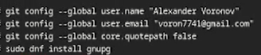

Базовая настройка git

## Создание ssh ключа.

Создание и добавление SSH ключа на github.

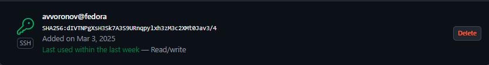

Добавление SSH ключа на github

## Создание PGP ключа.

Генерируем GPG ключ.

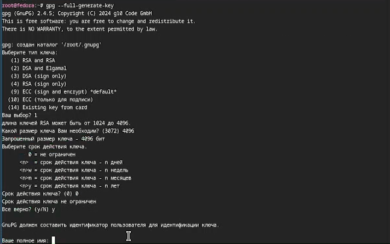

Генерация GPG ключа

Копируем GPG в буфер обмена.

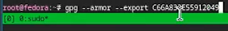

Копирование GPG ключ

## Добавление ключа на ГитХаб.

Добавляем GPG ключ на github.

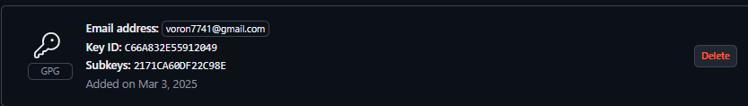

Добавление GPG ключа на github

## Настройка автоматических подписей коммитов git

Используем введенный email, указывая git где будут применять его при подписи коммитов.

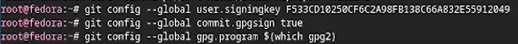

Настройка автоматических подписей коммитов git

## Настройка gh

Авторизуемся с помощью gh auth login.

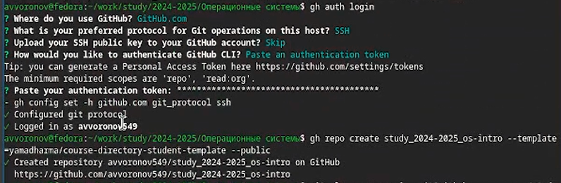

Настройка gh

## Создание и настройка репозитория курса.

Создаем репозиторий курса на основе шаблона.

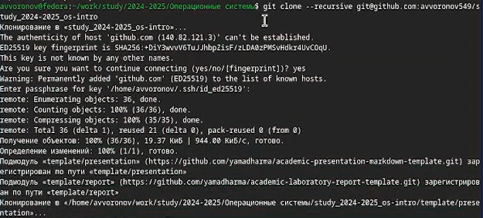

Создание репозитория

Отправляем файлы первой лабораторной работы на сервер.

Отправляем файлы на сервер.

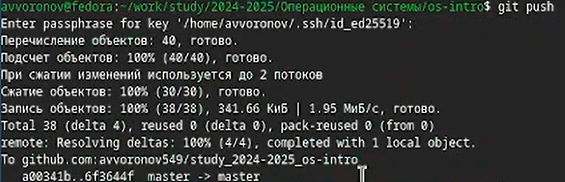

Отправление файлов на сервер

# Вывод

В результате выполнения данной лабораторной работы я приобрел необходимые навыки работы с гит, научился созданию репозиториев, gpg и ssh ключей, настроил каталог курса и авторизовался в gh.